# Cuckoo Eggs Dimension

Author

Deborah Elesie

Published

October 30, 2026

## Introduction

The Cuckoo bird is known for its unique reproductive strategy: brood parasitism. Instead of building their own nests, female cuckoos lay their eggs in the nests of other bird species (the hosts), leaving the host birds to incubate and raise the cuckoo chicks.

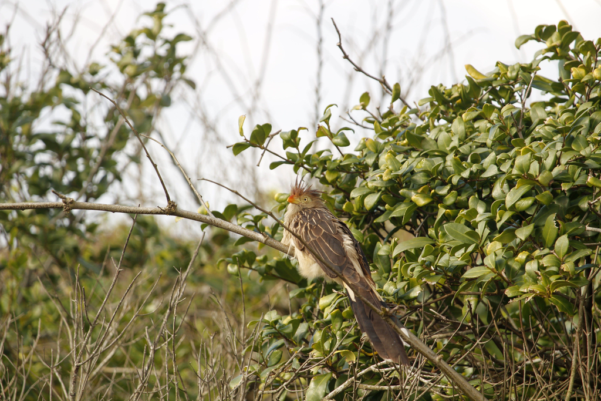

This report analyzes the physical dimensions of 120 cuckoo eggs found in the nests of six different host bird species. The dataset, sourced from the `DAAG` package (Maindonald et al., 2015), contains **three primary variables**: the length of the egg in millimeters, the breadth of the egg in millimeters, and the species of the host bird.

## Questions

For this report, the main objective is to check if there’s any significant difference between the egg sizes across the different host species. To answer this, we will look at two specific questions:

1. Is there a statistical difference in the **length** of eggs laid by the different bird species?
2. Is there a statistical difference in the **breadth** of eggs laid by the different bird species?

## Data Import and Inspection

Let’s start by importing the necessary packages and using basic inspection functions such as `head()`, `tail()`, and `str()` to ensure the data was loaded correctly and to understand its structure.

```r
# Load packages
library(tidyverse)
library(janitor)
library(car)

# Import data
cuckoo_data <- read_csv("https://raw.githubusercontent.com/xrander/bootcamp-test/master/data/cuckoo.csv") |>
  janitor::clean_names()

# Inspect data
head(cuckoo_data, 20)
```

```
# A tibble: 20 × 3
   length breadth species
    <dbl>   <dbl> <chr>
 1   21.7    16.1 Meadow Pipit
 2   22.6    17   Meadow Pipit
 3   20.9    16.2 Meadow Pipit
 4   21.6    16.2 Meadow Pipit
 5   22.2    16.9 Meadow Pipit
 6   22.5    16.9 Meadow Pipit
 7   22.2    17.3 Meadow Pipit
 8   24.3    16.8 Meadow Pipit
 9   22.3    16.8 Meadow Pipit
10   22.6    17   Meadow Pipit
11   20.1    16.5 Meadow Pipit
12   22      16.9 Meadow Pipit
13   22.8    16.5 Meadow Pipit
14   22      17   Meadow Pipit
15   22.4    17   Meadow Pipit
16   22.3    16.3 Meadow Pipit
17   20.6    16.2 Meadow Pipit
18   22.1    16.8 Meadow Pipit
19   21.9    17   Meadow Pipit
20   23      16.9 Meadow Pipit
```

```r
tail(cuckoo_data, 20)
```

```
# A tibble: 20 × 3
   length breadth species
    <dbl>   <dbl> <chr>
 1   22.1    16.2 Pied Wagtail
 2   21      17.1 Pied Wagtail
 3   22.6    16   Pied Wagtail
 4   21.9    16.9 Pied Wagtail
 5   24      17.2 Pied Wagtail
 6   19.8    15   Wren
 7   22.1    16   Wren
 8   21.5    16.2 Wren
 9   20.9    15.7 Wren
10   22      16.2 Wren
11   21      15.5 Wren
12   22.3    16   Wren
13   21      15.9 Wren
14   20.3    15.5 Wren
15   20.9    15.9 Wren
16   22      16   Wren
17   20      15.7 Wren
18   20.8    15.9 Wren
19   21.2    16   Wren
20   21      16   Wren
```

```r
str(cuckoo_data)
```

```
spc_tbl_ [120 × 3] (S3: spec_tbl_df/tbl_df/tbl/data.frame)
 $ length : num [1:120] 21.7 22.6 20.9 21.6 22.2 22.5 22.2 24.3 22.3 22.6 ...
 $ breadth: num [1:120] 16.1 17 16.2 16.2 16.9 16.9 17.3 16.8 16.8 17 ...
 $ species: chr [1:120] "Meadow Pipit" "Meadow Pipit" "Meadow Pipit" "Meadow Pipit" ...
 - attr(*, "spec")=
  .. cols(
  ..   length = col_double(),
  ..   breadth = col_double(),
  ..   species = col_character()
  .. )
 - attr(*, "problems")=<pointer: 0x0000029ac2effd30>
```

Confirm the number of species in the data set as recorded in the instruction material

```r
cuckoo_data |>
  count(species) |>
  knitr::kable(digits = 1)
```

| species | n |
| --- | --- |
| Hedge Sparrow | 14 |
| Meadow Pipit | 45 |
| Pied Wagtail | 15 |
| Robin | 16 |
| Tree Pipit | 15 |
| Wren | 15 |

## Data Conversion

To ensure uniformity across the report and tables, the numerical variables (`length` and `breadth`) are converted to 1 decimal place. This is done immediately after inspection so that all subsequent summaries, visualizations, and statistical tests use the uniform data.

```r
# Convert length and breadth to 1 decimal place
cuckoo_data <- cuckoo_data |>
  mutate(
    length = round(length, 1),
    breadth = round(breadth, 1)
  )
```

The data set with a uniform decimal

```r
cuckoo_data |>
  knitr::kable()
```

| length | breadth | species |
| --- | --- | --- |
| 21.7 | 16.1 | Meadow Pipit |
| 22.6 | 17.0 | Meadow Pipit |
| 20.9 | 16.2 | Meadow Pipit |
| 21.6 | 16.2 | Meadow Pipit |
| 22.2 | 16.9 | Meadow Pipit |
| 22.5 | 16.9 | Meadow Pipit |
| 22.2 | 17.3 | Meadow Pipit |
| 24.3 | 16.8 | Meadow Pipit |
| 22.3 | 16.8 | Meadow Pipit |
| 22.6 | 17.0 | Meadow Pipit |
| 20.1 | 16.5 | Meadow Pipit |
| 22.0 | 16.9 | Meadow Pipit |
| 22.8 | 16.5 | Meadow Pipit |
| 22.0 | 17.0 | Meadow Pipit |
| 22.4 | 17.0 | Meadow Pipit |
| 22.3 | 16.3 | Meadow Pipit |
| 20.6 | 16.2 | Meadow Pipit |
| 22.1 | 16.8 | Meadow Pipit |
| 21.9 | 17.0 | Meadow Pipit |
| 23.0 | 16.9 | Meadow Pipit |
| 22.0 | 17.0 | Meadow Pipit |
| 22.0 | 17.0 | Meadow Pipit |
| 22.1 | 17.3 | Meadow Pipit |
| 22.0 | 16.8 | Meadow Pipit |
| 19.6 | 15.8 | Meadow Pipit |
| 22.8 | 17.1 | Meadow Pipit |
| 22.0 | 16.9 | Meadow Pipit |
| 23.4 | 16.4 | Meadow Pipit |
| 23.8 | 16.4 | Meadow Pipit |
| 23.3 | 16.8 | Meadow Pipit |

[output cut: 90 more lines]

## Further Exploratory Data Analysis (EDA)

Aside Inspection that involves asking questions about the data other Exploratory Data Analysis concept was conducted to understand the distribution, central tendency, and spread of the cuckoo egg dimensions.

```r
summary(cuckoo_data) |>
  knitr::kable(digits = 1)
```

|  | length | breadth | species |
| --- | --- | --- | --- |
|  | Min. :19.60 | Min. :15.00 | Length :120 |
|  | 1st Qu.:21.90 | 1st Qu.:16.20 | N.unique : 6 |
|  | Median :22.35 | Median :16.60 | N.blank : 0 |
|  | Mean :22.45 | Mean :16.55 | Min.nchar: 4 |
|  | 3rd Qu.:23.23 | 3rd Qu.:17.00 | Max.nchar: 13 |
|  | Max. :25.00 | Max. :17.50 | NA |

```r
# Group_by summary of egg sizes BY SPECIES
cuckoo_data_summary <- cuckoo_data |>
  group_by(species) |>
  summarise(
    count = n(),
    avg_length = mean(length),
    avg_breadth = mean(breadth)
  )

cuckoo_data_summary |>
  knitr::kable()
```

| species | count | avg_length | avg_breadth |
| --- | --- | --- | --- |
| Hedge Sparrow | 14 | 23.11429 | 16.76429 |
| Meadow Pipit | 45 | 22.29333 | 16.74000 |
| Pied Wagtail | 15 | 22.88667 | 16.50000 |
| Robin | 16 | 22.55625 | 16.45000 |
| Tree Pipit | 15 | 23.08000 | 16.66667 |
| Wren | 15 | 21.12000 | 15.83333 |

## Data Analysis (Visualizations)

To get a better sense of the volume distribution and how egg sizes developed across species, let’s look at the boxplots in Figure 1 and Figure 2.

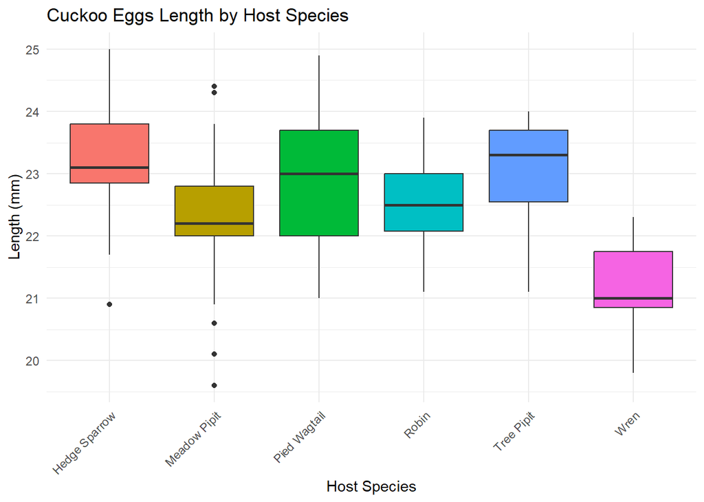

Figure 1: Distribution of Cuckoo Egg Length by Host Species

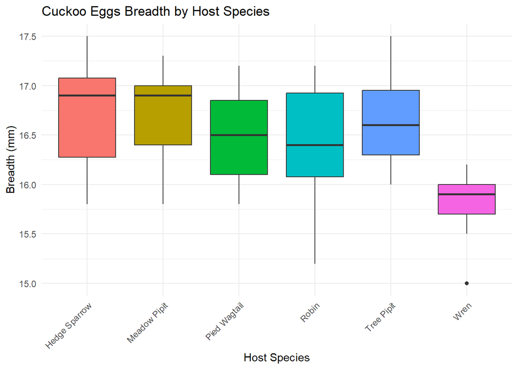

Figure 2: Distribution of Cuckoo Egg Breadth by Host Species

**Observation**

**Length (Figure 1):** The boxplot for length shows clear variations in egg size across species. The Tree Pipit displays the highest median egg length (around 23.4 mm), closely followed by the Hedge Sparrow (around 23.1 mm). The Pied Wagtail has a slightly lower median but the largest interquartile range (the tallest box), indicating a wider spread of egg lengths. In stark contrast, the Wren has the distinctly lowest median length (around 21.0 mm). The Meadow Pipit shows the most extreme variation, with a cluster of unusually small eggs (down to 19.6 mm) and two unusually large outliers above 24 mm. The Hedge Sparrow also has a single outlier egg at the lower end (exactly 20.9 mm).

**Breadth (Figure 2):** A similar pattern is visible in the breadth. Hedge Sparrow and Meadow Pipit eggs are generally the widest (highest medians, around 16.9 mm), while Wren eggs are the narrowest (median around 16.0 mm). The Wren also has a single outlier egg with a breadth of exactly 15.0 mm.

The visual separation in the medians and the spread of the boxes strongly suggest that the host species influences the egg dimensions. However, to prove that these differences are statistically significant and not just due to random chance, inferential testing is required.

## Inferential Statistical Analysis

To determine if the host bird species significantly influences the physical dimensions of the eggs, a One-Way Analysis of Variance (ANOVA) was performed. This test evaluates whether the means of the different groups are statistically equal. A significance level of α=0.05 was used.

**1. ANOVA: Difference in Egg Length**

**- Null Hypothesis (Ho):** There is no significant difference in the average length of eggs across the 6 bird species.

**- Alternative Hypothesis (H1):** At least one bird species has a significantly different average egg length.

```r
# One-way ANOVA for Egg LENGTH by Species
length_model <- aov(length ~ species, data = cuckoo_data)
summary(length_model)
```

```
             Df Sum Sq Mean Sq F value   Pr(>F)
species       5  42.81   8.562   10.45 2.85e-08 ***
Residuals   114  93.41   0.819
---
Signif. codes:  0 '***' 0.001 '**' 0.01 '*' 0.05 '.' 0.1 ' ' 1
```

**Result**

The ANOVA test yielded an F-statistic of 10.45 and a p-value of 2.85e-08. Because the p-value is significantly less than 0.05, we reject the null hypothesis. This indicates that there is a highly statistically significant difference in the length of cuckoo eggs depending on the host bird species. The visual differences observed in the length boxplot (Figure 1) are not due to random chance.

**2. ANOVA: Difference in Egg Breadth**

**- Null Hypothesis (Ho):** There is no significant difference in the average breadth of eggs across the 6 bird species.

**- Alternative Hypothesis (H1):** At least one bird species has a significantly different average egg breadth.

```r
# One-way ANOVA for Egg BREADTH by Species
breadth_model <- aov(breadth ~ species, data = cuckoo_data)
summary(breadth_model)
```

```
             Df Sum Sq Mean Sq F value   Pr(>F)
species       5  10.37  2.0746   10.88 1.41e-08 ***
Residuals   114  21.73  0.1906
---
Signif. codes:  0 '***' 0.001 '**' 0.01 '*' 0.05 '.' 0.1 ' ' 1
```

**Result**

The ANOVA test yielded an F-statistic of 10.88 and a p-value of 1.41e-08. Because the p-value is significantly less than 0.05, we reject the null hypothesis. This indicates that there is a highly statistically significant difference in the breadth of cuckoo eggs depending on the host bird species. The differences observed in the breadth boxplot (Figure 2) are statistically valid.

## Conclusion

To mathematically test these visual observations, a One-Way Analysis of Variance (ANOVA) was conducted for both egg length and breadth.

- For length, the ANOVA yielded a p-value of 2.85e-08.
- For breadth, the ANOVA yielded a p-value of 1.41e-08.

Because both p-values are significantly lower than the 0.05 significance level, we reject the null hypothesis. There is a highly statistically significant difference in both the length and breadth of cuckoo eggs depending on the host bird species.

These findings suggest that the cuckoo does not lay a uniform egg size across all nests. Instead, the dimensions of the eggs vary significantly by host species. This provides statistical evidence supporting the evolutionary theory that brood parasites may adapt the physical characteristics of their eggs to match the specific nest environment or the size of the host bird, thereby maximizing the chances of the egg being accepted and successfully incubated (Maindonald et al., 2015).

## Reference

Maindonald, J. H., Braun, W. J., & Braun, M. W. J. (2015). *Cuckoo eggs dataset (from the DAAG r package)*. Comprehensive R Archive Network (CRAN). https://CRAN.R-project.org/package=DAAG